# Day_4_A_B_testing_

# **Task 2: Real Industry project:**

**Develop a script for scraping email addresses from a list of domains • Ensure the script can locate and extract information from the “Impressum” page of each domain, • Handle different variations of email addresses (@, [ät], at, and so on...) • Can extract the Email Address from an Image. (Sometimes webmaster paste the Email as a JPEG or PNG, to prevent scraping**

```python
import requests
from bs4 import BeautifulSoup
from PIL import Image
import pytesseract #FOR OPTICAL CHARACTER RECOGNITION
import re
import openpyxl #FOR EXCEL FILE
import io

pytesseract.pytesseract.tesseract_cmd = r'/usr/bin/tesseract'
```

```python
def extractTextFromImage(imagePath): # Processes images and extracts text using OCR
    image = Image.open(imagePath)             # Open image using image path
    text = pytesseract.image_to_string(image) # Convert image to text
    return text
```

```python
def extractEMAILS(text): # Extracts email addresses from text
    emails=[]
    emailREGEX=[r'\b\S+\[at\]\S+\b',r'\b\S+@\S+\b',r'\b\S+\s*@\s*\S',r'[\w.-]+\(a\)[\w.-]+'] #For [a], @, spaces @ , (a)
    for regex in emailREGEX:
        addresses = re.findall(regex, text)
        emails.extend(addresses)
    return emails
```

```python
def scrapeEmails(domain): # Scraps email addresses from a domain's Impressum page

    emailsExtracted = []
    url = "https://www."+str(domain)+"/impressum"

    try: #Try except clause used to handle errors

        response = requests.get(url)                        #Go to url
        soup = BeautifulSoup(response.text, 'html.parser')  #Parse

        text = soup.get_text()                              #convert to text form
        emailsExtracted.extend(extractEMAILS(text))         # Finds email addresses in text and add to list

         # Finds email addresses in images
        imageTags = soup.find_all('img')
        for imageTAG in imageTags:
                imageURL = imageTAG['src']
                if imageURL.endswith('.jpg') or imageURL.endswith('.jpeg') or imageURL.endswith('.png'):
                    # Processes the image
                    imageResponse = requests.get(imageURL)
                    imagePath = f"{domain}_image.jpg"  # Save the image locally
                    with open(imagePath, 'wb') as f:
                        f.write(imageResponse.content)
                    text = extractTextFromImage(imagePath)
                    emailsExtracted.extend(extractEMAILS(text))

    except requests.exceptions.RequestException as e:
            print("Error has occurred while accessing",url,"The Error is: ",str(e))

    return emailsExtracted
```

```python
#List of domains as mentioned in question
domains =['peersociallending.com',
          'kreditvergleich-kostenlos.net',
          'matblog.de',
          'malta-tours.de',
          'wiseclerk.com' ,
          'rentnerkredite.com',
          'klaudija.de',
          'websitevalue.co.uk',
          'freizeitcafe.info',
          'ladenbau.de',
          'bierspot.de',
          'biboxs.com',
          'finance-it-blog.de',
          'guenstigerkreditvergleich.com',
          'fintech-intel.com',
          'selbst-schuld.com',
          'elternkredit.com',
          'finlord.cz',
          'vj-coach.de', #Starting from here the rest of the domains seem to not be accessible
# 'urlaub-in-thailand.com',
'findle.top',
'niederrheinzeitung.de',
'finanziell-umdenken.blogspot.com',
 'midblo.org',
'pc-welt.wiki'
'sunshine-island.eu',
'cloudbiz.one',
'frag-den-heimwerker.com',
'binoro.de',
'siteurl.org',
'franchiseportal.at'
'mountainstatescfc.org',
'crowdstreet.de']

# Scrape email addresses from domains and store in a list
emailsList = []
for domain in domains:
    print("Extracting Email Addresses from Domain: ",domain,'...')
    emailsList.extend(scrapeEmails(domain))

# Writing email addresses along with domain to an Excel sheet
workbook = openpyxl.Workbook()
sheet = workbook.active
sheet.append(["Domain Name", "Email Address"])

for domain, email in zip(domains, emailsList):
    sheet.append([domain, email])

workbook.save('EmailAddresses.xlsx')
```

```
Extracting Email Addresses from Domain:  peersociallending.com ...
Extracting Email Addresses from Domain:  kreditvergleich-kostenlos.net ...
Extracting Email Addresses from Domain:  matblog.de ...
Extracting Email Addresses from Domain:  malta-tours.de ...
Extracting Email Addresses from Domain:  wiseclerk.com ...
Extracting Email Addresses from Domain:  rentnerkredite.com ...
Extracting Email Addresses from Domain:  klaudija.de ...
Extracting Email Addresses from Domain:  websitevalue.co.uk ...
Extracting Email Addresses from Domain:  freizeitcafe.info ...
Extracting Email Addresses from Domain:  ladenbau.de ...
Extracting Email Addresses from Domain:  bierspot.de ...
Extracting Email Addresses from Domain:  biboxs.com ...
Extracting Email Addresses from Domain:  finance-it-blog.de ...
Extracting Email Addresses from Domain:  guenstigerkreditvergleich.com ...
Extracting Email Addresses from Domain:  fintech-intel.com ...
Extracting Email Addresses from Domain:  selbst-schuld.com ...
Extracting Email Addresses from Domain:  elternkredit.com ...
Extracting Email Addresses from Domain:  finlord.cz ...
Error has occurred while accessing https://www.finlord.cz/impressum The Error is:  HTTPSConnectionPool(host='finlord.cz', port=443): Max retries exceeded with url: /impressum (Caused by ConnectTimeoutError(<urllib3.connection.HTTPSConnection object at 0x799b73ca0910>, 'Connection to finlord.cz timed…
Extracting Email Addresses from Domain:  vj-coach.de ...
Extracting Email Addresses from Domain:  findle.top ...
Extracting Email Addresses from Domain:  niederrheinzeitung.de ...
```

[output not shown]

[output not shown]

[output not shown]

```
Error has occurred while accessing https://www.siteurl.org/impressum The Error is:  HTTPSConnectionPool(host='www.siteurl.org', port=443): Max retries exceeded with url: /impressum (Caused by SSLError(CertificateError("hostname 'www.siteurl.org' doesn't match either of 'xiaojinzi.com', 'www.xiaojinz…
Extracting Email Addresses from Domain:  franchiseportal.atmountainstatescfc.org ...
Error has occurred while accessing https://www.franchiseportal.atmountainstatescfc.org/impressum The Error is:  HTTPSConnectionPool(host='www.franchiseportal.atmountainstatescfc.org', port=443): Max retries exceeded with url: /impressum (Caused by NewConnectionError('<urllib3.connection.HTTPSConnect…
Extracting Email Addresses from Domain:  crowdstreet.de ...
```

[output not shown]

```
Error has occurred while accessing https://www.crowdstreet.de/impressum The Error is:  HTTPSConnectionPool(host='www.crowdstreet.de', port=443): Max retries exceeded with url: /impressum (Caused by SSLError(CertificateError("hostname 'www.crowdstreet.de' doesn't match either of '*.do.de', 'do.de'"))…
```

# **Task 3**

```python
import pandas as pd
import matplotlib.pyplot as plt

# Load the retail services CSV file
df = pd.read_csv("/content/drive/MyDrive/Data Science Internship/week_2/Day_4/retail_services.csv")
```

```python
df.head()
```

|  | time.index | time.month | time.month name | time.period | time.year | data.inventories.all department stores | data.inventories.all other home furnishings stores | data.inventories.all other merchandise stores | data.inventories.appliances and other electronics stores | data.inventories.auto and other motor vehicles | ... | data.sales.retail trade and food services, ex auto | data.sales.retail trade, ex auto | data.sales.shoe stores | data.sales.sporting goods stores | data.sales.sporting goods, hobby, book, and music stores | data.sales.supermarkets and other grocery (except convenience) stores | data.sales.used car dealers | data.sales.used merchandise stores | data.sales.warehouse clubs and superstores | data.sales.women's clothing stores |
| --- | --- | --- | --- | --- | --- | --- | --- | --- | --- | --- | --- | --- | --- | --- | --- | --- | --- | --- | --- | --- | --- |
| 0 | 1 | 1 | Jan | Jan1992 | 1992 | 0 | 0 | 0 | 0 | 0 | ... | 116565 | 100872 | 1206 | 972 | 3439 | 0 | 1744 | 371 | 2579 | 1873 |
| 1 | 2 | 2 | Feb | Feb1992 | 1992 | 0 | 0 | 0 | 0 | 0 | ... | 115862 | 100027 | 1265 | 1100 | 3264 | 0 | 1990 | 402 | 2615 | 1991 |
| 2 | 3 | 3 | Mar | Mar1992 | 1992 | 0 | 0 | 0 | 0 | 0 | ... | 124200 | 107352 | 1463 | 1214 | 3473 | 0 | 2177 | 419 | 2838 | 2403 |
| 3 | 4 | 4 | Apr | Apr1992 | 1992 | 0 | 0 | 0 | 0 | 0 | ... | 127587 | 111093 | 1675 | 1267 | 3523 | 0 | 2601 | 393 | 2984 | 2665 |
| 4 | 5 | 5 | May | May1992 | 1992 | 0 | 0 | 0 | 0 | 0 | ... | 133608 | 115960 | 1560 | 1293 | 3545 | 0 | 2171 | 435 | 3257 | 2752 |

5 rows × 197 columns

```python
df.dropna(inplace=True)
```

```python
df.describe()
```

|  | time.index | time.month | time.year | data.inventories.all department stores | data.inventories.all other home furnishings stores | data.inventories.all other merchandise stores | data.inventories.appliances and other electronics stores | data.inventories.auto and other motor vehicles | data.inventories.automobile dealers | data.inventories.automotive parts and tire stores | ... | data.sales.retail trade and food services, ex auto | data.sales.retail trade, ex auto | data.sales.shoe stores | data.sales.sporting goods stores | data.sales.sporting goods, hobby, book, and music stores | data.sales.supermarkets and other grocery (except convenience) stores | data.sales.used car dealers | data.sales.used merchandise stores | data.sales.warehouse clubs and superstores | data.sales.women's clothing stores |
| --- | --- | --- | --- | --- | --- | --- | --- | --- | --- | --- | --- | --- | --- | --- | --- | --- | --- | --- | --- | --- | --- |
| count | 289.000000 | 289.000000 | 289.000000 | 289.0 | 289.0 | 289.0 | 289.0 | 289.0 | 289.0 | 289.0 | ... | 289.000000 | 289.000000 | 289.000000 | 289.000000 | 289.000000 | 289.000000 | 289.000000 | 289.000000 | 289.000000 | 289.000000 |
| mean | 145.000000 | 6.480969 | 2003.543253 | 0.0 | 0.0 | 0.0 | 0.0 | 0.0 | 0.0 | 0.0 | ... | 242476.089965 | 211132.491349 | 2089.602076 | 2498.768166 | 6208.961938 | 25135.124567 | 5144.723183 | 861.743945 | 19464.089965 | 2957.148789 |
| std | 83.571327 | 3.467180 | 6.961130 | 0.0 | 0.0 | 0.0 | 0.0 | 0.0 | 0.0 | 0.0 | ... | 72916.757891 | 63030.803887 | 500.439124 | 934.727674 | 1815.035633 | 19902.112653 | 1631.006836 | 276.348091 | 11796.867031 | 719.518344 |
| min | 1.000000 | 1.000000 | 1992.000000 | 0.0 | 0.0 | 0.0 | 0.0 | 0.0 | 0.0 | 0.0 | ... | 115862.000000 | 100027.000000 | 1161.000000 | 972.000000 | 3204.000000 | 0.000000 | 1583.000000 | 371.000000 | 2579.000000 | 1565.000000 |
| 25% | 73.000000 | 3.000000 | 1998.000000 | 0.0 | 0.0 | 0.0 | 0.0 | 0.0 | 0.0 | 0.0 | ... | 177182.000000 | 155484.000000 | 1757.000000 | 1754.000000 | 5227.000000 | 0.000000 | 4066.000000 | 702.000000 | 7758.000000 | 2440.000000 |
| 50% | 145.000000 | 6.000000 | 2004.000000 | 0.0 | 0.0 | 0.0 | 0.0 | 0.0 | 0.0 | 0.0 | ... | 240415.000000 | 210772.000000 | 2006.000000 | 2319.000000 | 6004.000000 | 34485.000000 | 5348.000000 | 811.000000 | 19000.000000 | 2780.000000 |
| 75% | 217.000000 | 9.000000 | 2010.000000 | 0.0 | 0.0 | 0.0 | 0.0 | 0.0 | 0.0 | 0.0 | ... | 301828.000000 | 260358.000000 | 2356.000000 | 3109.000000 | 6652.000000 | 41657.000000 | 6339.000000 | 983.000000 | 30329.000000 | 3415.000000 |
| max | 289.000000 | 12.000000 | 2016.000000 | 0.0 | 0.0 | 0.0 | 0.0 | 0.0 | 0.0 | 0.0 | ... | 423095.000000 | 368440.000000 | 3985.000000 | 6444.000000 | 13025.000000 | 51216.000000 | 8762.000000 | 1633.000000 | 45540.000000 | 5606.000000 |

8 rows × 195 columns

```python
df.info()
```

```
<class 'pandas.core.frame.DataFrame'>
RangeIndex: 289 entries, 0 to 288
Columns: 197 entries, time.index to data.sales.women's clothing stores
dtypes: float64(9), int64(186), object(2)
memory usage: 444.9+ KB
```

```python
column_list=list(df.columns)
print(column_list)
```

```
['time.index', 'time.month', 'time.month name', 'time.period', 'time.year', 'data.inventories.all department stores', 'data.inventories.all other home furnishings stores', 'data.inventories.all other merchandise stores', 'data.inventories.appliances and other electronics stores', 'data.inventories.a…
```

**1.How has retail economic activity in the United States changed over the past five years?**

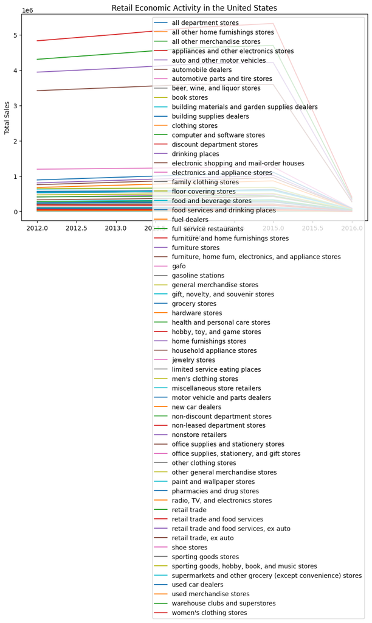

```python
# 1) How has retail economic activity in the United States changed over the past five years?

#Seperating & Combining only relevant data for Q1 i.e all sales column and year column:
salesCOLS = [col for col in df.columns if col.startswith('data.sales')]   #Extracting  relevant sales column names
dataQ1 = df[['time.year'] + salesCOLS].copy()                             #Saving data from relevant columns

dataQ1=dataQ1.loc[dataQ1['time.year']>=2012]                                #As we want to compare of only past 5 years


yearlySales = dataQ1.groupby('time.year')[salesCOLS].sum()                  #Calculating yearly sales:

# Visualizing Results:
import matplotlib.pyplot as plt

plt.figure(figsize=(10, 6))
for col in salesCOLS:
    plt.plot(yearlySales.index, yearlySales[col], label=col.split('.')[-1])

plt.xlabel('Year')
plt.ylabel('Total Sales')
plt.title('Retail Economic Activity in the United States')
plt.legend()
plt.show()
```

**2. What are the key differences between the Advance Monthly Retail Trade Survey (MARTS) and the Annual Retail Trade Survey (ARTS)?**

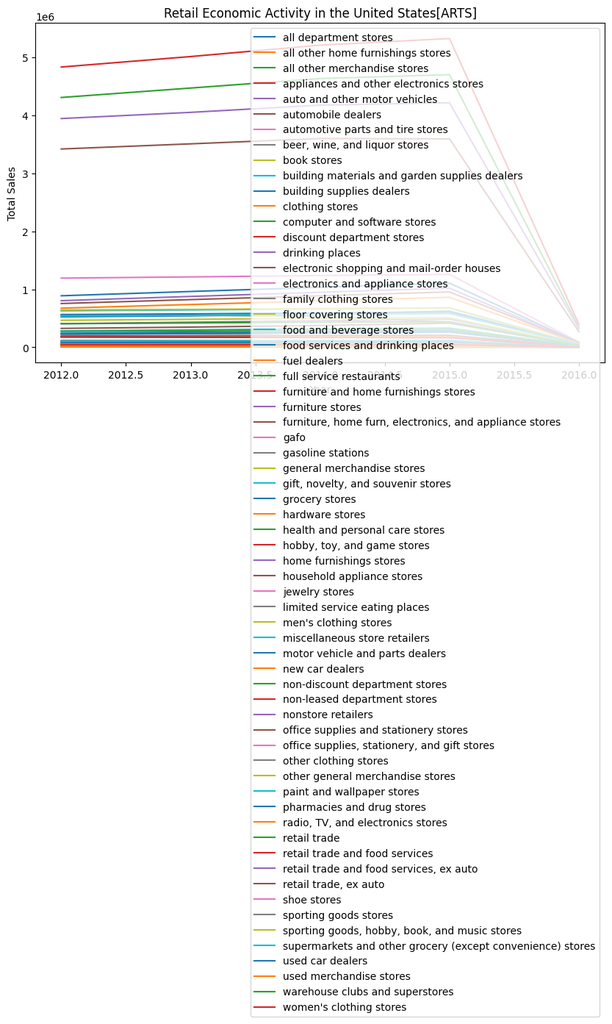

```python
# 2) What are the key differences between the Advance Monthly Retail Trade Survey (MARTS)
# and the Annual Retail Trade Survey (ARTS)?

#MARTS is conducted on monthly basis whiel ARTS is conducted yearly
# & includes data for sales, inventories, and other economic indicators

#ARTS:
yearlySales = dataQ1.groupby('time.year')[salesCOLS].sum()                  #Calculating yearly sales:

# Visualizing Results:
import matplotlib.pyplot as plt

plt.figure(figsize=(10, 6))
for col in salesCOLS:
    plt.plot(yearlySales.index, yearlySales[col], label=col.split('.')[-1])

plt.xlabel('Year')
plt.ylabel('Total Sales')
plt.title('Retail Economic Activity in the United States[ARTS]')
plt.legend()
plt.show()
```

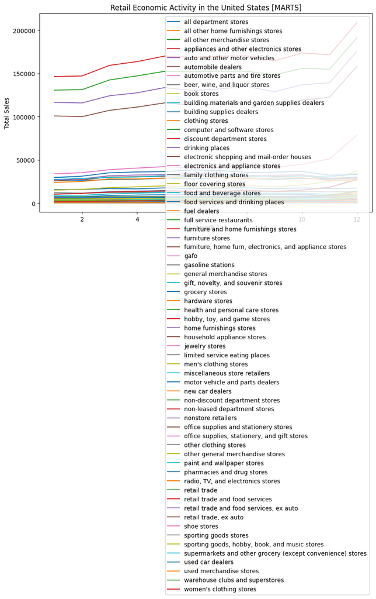

```python
#MARTS of year (1992):

dataQ2sales=[col for col in df.columns if col.startswith('data.sales')]   #Extracting  relevant sales column names
dataQ2 = df[['time.month']+['time.year'] + dataQ2sales].copy()                             #Saving data from relevant columns
dataQ2.head()

dataQ2=dataQ2.loc[dataQ2['time.year']==1992]

monthlySales = dataQ2.groupby('time.month')[salesCOLS].sum()                  #Calculating yearly sales:

# Visualizing Results:
import matplotlib.pyplot as plt

plt.figure(figsize=(10, 6))
for col in salesCOLS:
    plt.plot(monthlySales.index, monthlySales[col], label=col.split('.')[-1])

plt.xlabel('Month')
plt.ylabel('Total Sales')
plt.title('Retail Economic Activity in the United States [MARTS]')
plt.legend()
plt.show()
```

**3. Can we identify any seasonal patterns or trends in monthly retail sales data?**

```python
print("Yes according to the graph above the sales go up towards the end of year i.e after november")
```

```
Yes according to the graph above the sales go up towards the end of year i.e after november
```

```python
df.head()
```

|  | time.index | time.month | time.month name | time.period | time.year | data.inventories.all department stores | data.inventories.all other home furnishings stores | data.inventories.all other merchandise stores | data.inventories.appliances and other electronics stores | data.inventories.auto and other motor vehicles | ... | data.sales.retail trade and food services, ex auto | data.sales.retail trade, ex auto | data.sales.shoe stores | data.sales.sporting goods stores | data.sales.sporting goods, hobby, book, and music stores | data.sales.supermarkets and other grocery (except convenience) stores | data.sales.used car dealers | data.sales.used merchandise stores | data.sales.warehouse clubs and superstores | data.sales.women's clothing stores |
| --- | --- | --- | --- | --- | --- | --- | --- | --- | --- | --- | --- | --- | --- | --- | --- | --- | --- | --- | --- | --- | --- |
| 0 | 1 | 1 | Jan | Jan1992 | 1992 | 0 | 0 | 0 | 0 | 0 | ... | 116565 | 100872 | 1206 | 972 | 3439 | 0 | 1744 | 371 | 2579 | 1873 |
| 1 | 2 | 2 | Feb | Feb1992 | 1992 | 0 | 0 | 0 | 0 | 0 | ... | 115862 | 100027 | 1265 | 1100 | 3264 | 0 | 1990 | 402 | 2615 | 1991 |
| 2 | 3 | 3 | Mar | Mar1992 | 1992 | 0 | 0 | 0 | 0 | 0 | ... | 124200 | 107352 | 1463 | 1214 | 3473 | 0 | 2177 | 419 | 2838 | 2403 |
| 3 | 4 | 4 | Apr | Apr1992 | 1992 | 0 | 0 | 0 | 0 | 0 | ... | 127587 | 111093 | 1675 | 1267 | 3523 | 0 | 2601 | 393 | 2984 | 2665 |
| 4 | 5 | 5 | May | May1992 | 1992 | 0 | 0 | 0 | 0 | 0 | ... | 133608 | 115960 | 1560 | 1293 | 3545 | 0 | 2171 | 435 | 3257 | 2752 |

5 rows × 197 columns

**4. How does e-commerce activity compare to traditional retail sales on a quarterly basis?**

```python
column_list=list(df.columns)
print(column_list)
```

[output not shown]

```python
# Convert 'time.index' to date time formate
dataq4=df.copy()
dataq4['time.period']=pd.to_datetime(dataq4['time.period'])
```

```python
# Extracting relevant columns for e-commerce and traditional retail sales
# and Grouping the data by quarters and calculating the sum of sales for each category
dataq4['quarter']=dataq4['time.period'].dt.to_period('Q')
ecomerce=dataq4.groupby('quarter')['data.sales.electronic shopping and mail-order houses'].sum()
traditional=dataq4.groupby('quarter')['data.sales.retail trade'].sum()
# converting the period index to a numeric representation
ecomerce.index = ecomerce.index.to_timestamp()
traditional.index = traditional.index.to_timestamp()
```

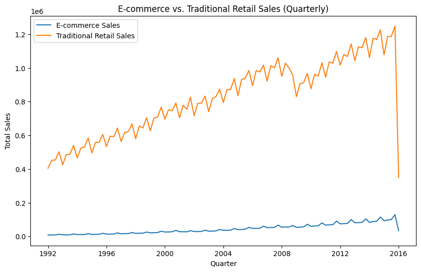

```python
# Plotting the quarterly sales comparison
plt.figure(figsize=(10, 6))
plt.plot(ecomerce.index, ecomerce, label='E-commerce Sales')
plt.plot(traditional.index, traditional, label='Traditional Retail Sales')
plt.xlabel('Quarter')
plt.ylabel('Total Sales')
plt.title('E-commerce vs. Traditional Retail Sales (Quarterly)')
plt.legend()
plt.show()
```

```python
print("Clearly traditional retail has higher sales")
```

```
Clearly traditional retail has higher sales
```

[figure not shown]

```python
# Calculate growth rates for different sectors
dataq5 = df.copy()

# Convert the 'time.index' column to datetime format
dataq5['time.index'] = pd.to_datetime(dataq5['time.index'])

sectors = [
    'data.sales.clothing stores',
    'data.sales.electronic shopping and mail-order houses',
    'data.sales.supermarkets and other grocery (except convenience) stores'
    # ... Add more sectors as needed
]

growth_rates = {}

for sector in sectors:
    dataq5[sector + 'Growth'] = dataq5[sector].pct_change(periods=12) * 100

# Plot growth rates for each sector
plt.figure(figsize=(10, 6))

for sector in sectors:
    plt.plot(dataq5['time.index'], dataq5[sector + 'Growth'], label=sector.split('.')[-1])

plt.xlabel('Year')
plt.ylabel('Growth Rate')
plt.title('Growth Rates of Specific Retail Sectors')
plt.legend()
plt.show()
```